# Chapter 1

Hanchao Yan

2025-02-27

# 使用LLM辅助R语言编程

事前准备：

1. 任意大语言模型，示例：[通义千问](https://tongyi.aliyun.com/)
2. 设置工作目录：小齿轮 - Set As Working Directory

大语言模型的Prompt通常是下面的结构

1. （可选）定义身份：你是一名专业的数据科学家，我是零代码基础的用户。
2. 定义任务：我将提供给你一份CSV格式的数据集（文件名：第一章.csv），数据集使用了GBK编码，请你使用R语言代码读取数据，这段代码能够对每一列做计算样本均值、样本标准差、中位数、最小值、最大值，并以较美观的方式输出。由于我是零代码基础的用户，你应当使用尽可能容易理解的代码，尽量避免引入不必要的包，代码应当有详细的注释。
3. （可选）示例输入：（这个案例中我们不需要提供输入定义）
4. （可选）示例输出：你的结果应当以Code Block的形式输出，无需其他输出。

## 第一轮：描述统计，计算简单的统计数值

**输入PROMPT**：你是一名专业的数据科学家，我是零代码基础的用户。我将提供给你一份CSV格式的数据集（文件名：第一章.csv），数据集使用了GBK编码，请你使用R语言代码读取数据，这段代码能够对每一列做计算样本均值、样本标准差、中位数、最小值、最大值，并以较美观的方式输出。由于我是零代码基础的用户，你应当使用尽可能容易理解的代码，尽量避免引入不必要的包，代码应当有详细的注释。你的结果应当以Code Block的形式输出，无需其他输出。

**LLM输出**

```r
# 设置工作目录为数据集所在的路径（请根据实际情况修改）
# setwd("你的文件路径")

# 使用 read.csv 函数读取 CSV 文件，指定 encoding 参数为 "GBK"
# header = TRUE 表示文件第一行是列名
data <- read.csv("第1章.csv", header = TRUE, encoding = "GBK", fileEncoding = "GBK")

# 查看数据集的前几行，确认数据是否正确加载
head(data)
```

```
##       因变量 通话总量  大网占比   小网占比
## 1  0.2126197 2.822822 0.9037594 0.21954887
## 2  0.2756156 2.628389 0.9717647 0.02823529
## 3  0.1687526 2.537819 0.9913043 0.22318841
## 4  0.1544425 3.201124 0.8986784 0.11264947
## 5  0.3337990 3.132580 0.8467207 0.15327929
## 6 -0.2064917 0.845098 1.0000000 0.00000000
```

```r
# 创建一个空的数据框，用于存储每一列的统计结果
summary_stats <- data.frame(
  Column = character(),   # 列名
  Mean = numeric(),       # 样本均值
  SD = numeric(),         # 标准差
  Median = numeric(),     # 中位数
  Min = numeric(),        # 最小值
  Max = numeric(),        # 最大值
  stringsAsFactors = FALSE
)

# 遍历数据框中的每一列
for (col_name in names(data)) {
  col_data <- data[[col_name]]  # 获取当前列的数据

  # 计算统计量
  mean_val <- mean(col_data, na.rm = TRUE)  # 样本均值，忽略缺失值
  sd_val <- sd(col_data, na.rm = TRUE)      # 样本标准差，忽略缺失值
  median_val <- median(col_data, na.rm = TRUE)  # 中位数，忽略缺失值
  min_val <- min(col_data, na.rm = TRUE)    # 最小值，忽略缺失值
  max_val <- max(col_data, na.rm = TRUE)    # 最大值，忽略缺失值

  # 将当前列的统计结果添加到 summary_stats 数据框中
  summary_stats <- rbind(summary_stats, data.frame(
    Column = col_name,
    Mean = mean_val,
    SD = sd_val,
    Median = median_val,
    Min = min_val,
    Max = max_val
  ))
}

# 输出统计结果，使用 knitr::kable() 美化输出（如果需要更美观的表格格式，可以安装 knitr 包）
# 如果不想引入额外包，直接打印 summary_stats 即可
print(summary_stats)
```

```
##     Column      Mean        SD    Median         Min       Max
## 1   因变量 0.1930176 0.1324444 0.1870535 -0.49801016 0.9925818
## 2 通话总量 2.5804381 0.4083604 2.5831988  0.77815125 3.6009729
## 3 大网占比 0.8457207 0.1538765 0.8983452  0.09867452 1.0000000
## 4 小网占比 0.2521307 0.2112832 0.1983730  0.00000000 0.9734904
```

## 第二轮：描述统计，绘制直方图

从第二轮开始，如果您在同一个对话框中与LLM交互，那么他理应记得前文提出的身份设定，故此处可以直接写任务要求。

**输入PROMPT**：我发现数据中包含四列，分别为“因变量”、“通话总量”、“大网占比”、“小网占比”。请你生成R代码，绘制每一列数据的直方图，四张直方图应当在一行中。请你使用尽可能容易理解的代码、尽量避免引入不必要的包，代码应当有详细的注释。你的结果应当以Code Block的形式输出，无需其他输出。

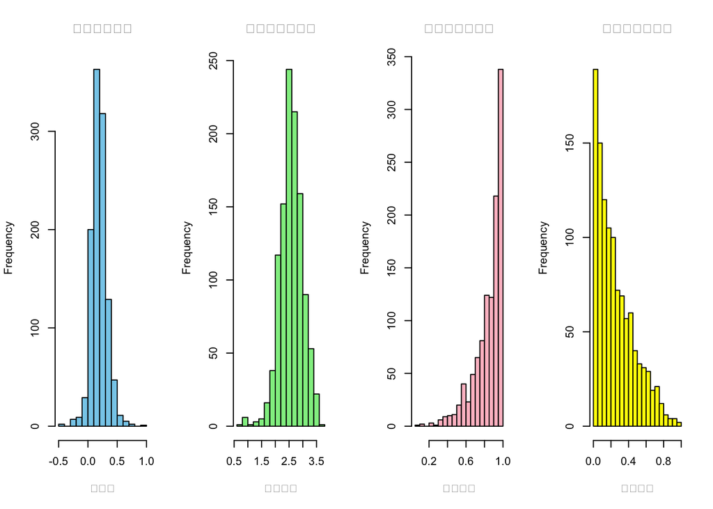

```r
# 加载数据（假设数据已经按照之前的代码加载到 data 中）
# 如果没有加载，请先运行之前的读取代码

# 创建一个 1x4 的画布，用于在一行中绘制四个直方图
par(mfrow = c(1, 4))  # 设置图形布局为 1 行 4 列

# 绘制“因变量”的直方图
hist(data$因变量,
     main = "因变量直方图",
     xlab = "因变量",
     col = "skyblue",
     breaks = 20)  # breaks 参数控制直方图的柱子数量

# 绘制“通话总量”的直方图
hist(data$通话总量,
     main = "通话总量直方图",
     xlab = "通话总量",
     col = "lightgreen",
     breaks = 20)

# 绘制“大网占比”的直方图
hist(data$大网占比,
     main = "大网占比直方图",
     xlab = "大网占比",
     col = "pink",
     breaks = 20)

# 绘制“小网占比”的直方图
hist(data$小网占比,
     main = "小网占比直方图",
     xlab = "小网占比",
     col = "yellow",
     breaks = 20)
```

可以看到，上面的图中没能正确显示中文。我们需要和LLM交互来修正这一问题。

**输入PROMPT**：你已经生成了直方图，然而图中的中文没有正常显示。请修正你的代码，使得代码无论在Windows平台还是在Mac平台上都可以正确显示中文。请你使用尽可能容易理解的代码、尽量避免引入不必要的包，代码应当有详细的注释。你的结果应当以Code Block的形式输出，无需其他输出。

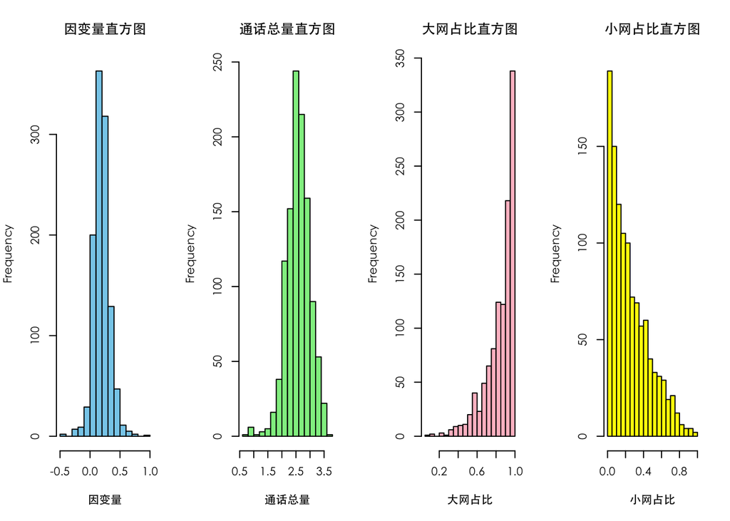

```r
# 设置字体以支持中文显示
# 在 Mac 平台上使用 "STHeiti" 字体
if (.Platform$OS.type == "unix") {  # 包括 macOS 和 Linux
  family <- "STHeiti"  # 指定 macOS 的中文字体
} else if (.Platform$OS.type == "windows") {
  windowsFonts(simsum = windowsFont("simsun"))  # 设置 Windows 的宋体字体
  family <- "simsum"
}

# 创建一个 1x4 的画布，用于在一行中绘制四个直方图
par(mfrow = c(1, 4))  # 设置图形布局为 1 行 4 列

# 绘制“因变量”的直方图
hist(data$因变量,
     main = "因变量直方图",
     xlab = "因变量",
     col = "skyblue",
     breaks = 20,
     family = family)  # 使用指定的字体

# 绘制“通话总量”的直方图
hist(data$通话总量,
     main = "通话总量直方图",
     xlab = "通话总量",
     col = "lightgreen",
     breaks = 20,
     family = family)

# 绘制“大网占比”的直方图
hist(data$大网占比,
     main = "大网占比直方图",
     xlab = "大网占比",
     col = "pink",
     breaks = 20,
     family = family)

# 绘制“小网占比”的直方图
hist(data$小网占比,
     main = "小网占比直方图",
     xlab = "小网占比",
     col = "yellow",
     breaks = 20,
     family = family)
```

## 第三轮：描述统计，绘制箱线图

**输入PROMPT**：接下来对于“因变量”列，称大于中位数的叫做“高”、小于中位数的叫做“低”。请你绘制其他三列（即“通话总量”、“大网占比”、“小网占比”）关于因变量高低的箱线图，三张箱线图应当在一行中。图片需要有正常的中文显示，请你使用尽可能容易理解的代码、尽量避免引入不必要的包，代码应当有详细的注释。你的结果应当以Code Block的形式输出，无需其他输出。

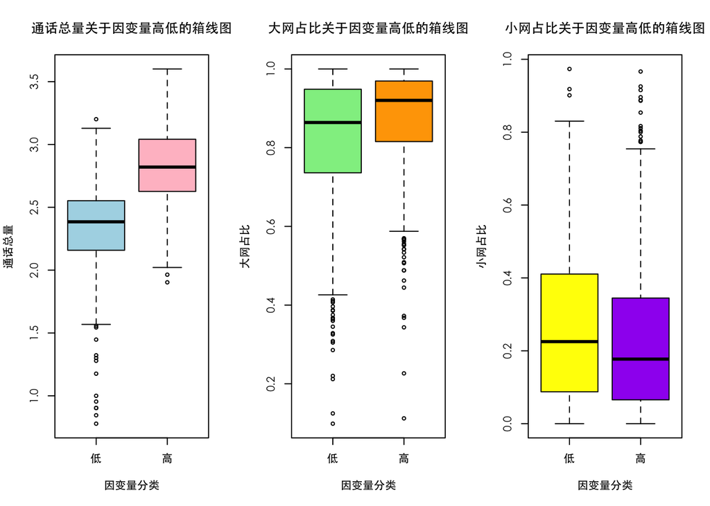

```r
# 设置字体以支持中文显示
# 在 Mac 平台上使用 "STHeiti" 字体
if (.Platform$OS.type == "unix") {  # 包括 macOS 和 Linux
  family <- "STHeiti"  # 指定 macOS 的中文字体
} else if (.Platform$OS.type == "windows") {
  windowsFonts(simsum = windowsFont("simsun"))  # 设置 Windows 的宋体字体
  family <- "simsum"
}

# 计算“因变量”列的中位数
median_因变量 <- median(data$因变量, na.rm = TRUE)

# 根据中位数将“因变量”分为“高”和“低”两组
data$因变量分类 <- ifelse(data$因变量 > median_因变量, "高", "低")

# 创建一个 1x3 的画布，用于在一行中绘制三个箱线图
par(family = family)
par(mfrow = c(1, 3))  # 设置图形布局为 1 行 3 列

# 绘制“通话总量”关于因变量高低的箱线图
boxplot(通话总量 ~ 因变量分类,
        data = data,
        main = "通话总量关于因变量高低的箱线图",
        xlab = "因变量分类",
        ylab = "通话总量",
        col = c("lightblue", "pink"),
        horizontal = FALSE,
        family = family)  # 水平方向设置为 FALSE

# 绘制“大网占比”关于因变量高低的箱线图
boxplot(大网占比 ~ 因变量分类,
        data = data,
        main = "大网占比关于因变量高低的箱线图",
        xlab = "因变量分类",
        ylab = "大网占比",
        col = c("lightgreen", "orange"),
        horizontal = FALSE,
        family = family)

# 绘制“小网占比”关于因变量高低的箱线图
boxplot(小网占比 ~ 因变量分类,
        data = data,
        main = "小网占比关于因变量高低的箱线图",
        xlab = "因变量分类",
        ylab = "小网占比",
        col = c("yellow", "purple"),
        horizontal = FALSE,
        family = family)
```

## 第四轮：回归分析

**输入PROMPT**：请你使用R建立线性回归模型，以“因变量”列为因变量，以“通话总量”、“大网占比”、“小网占比”为自变量，并输出回归模型的详细结果。请你使用尽可能容易理解的代码、尽量避免引入不必要的包，代码应当有详细的注释。你的结果应当以Code Block的形式输出，无需其他输出。

```r
# 建立线性回归模型，以“因变量”列为因变量，“通话总量”、“大网占比”、“小网占比”为自变量
model <- lm(因变量 ~ 通话总量 + 大网占比 + 小网占比, data = data)

# 输出回归模型的详细结果
summary(model)
```

```
##
## Call:
## lm(formula = 因变量 ~ 通话总量 + 大网占比 + 小网占比,
##     data = data)
##
## Residuals:
##      Min       1Q   Median       3Q      Max
## -0.62789 -0.04540 -0.01281  0.03177  0.62598
##
## Coefficients:
##              Estimate Std. Error t value Pr(>|t|)
## (Intercept) -0.488566   0.026160 -18.676  < 2e-16 ***
## 通话总量     0.235569   0.006519  36.135  < 2e-16 ***
## 大网占比     0.089486   0.022915   3.905 9.98e-05 ***
## 小网占比    -0.007807   0.016586  -0.471    0.638
## ---
## Signif. codes:  0 '***' 0.001 '**' 0.01 '*' 0.05 '.' 0.1 ' ' 1
##
## Residual standard error: 0.08826 on 1119 degrees of freedom
## Multiple R-squared:  0.5571, Adjusted R-squared:  0.5559
## F-statistic: 469.1 on 3 and 1119 DF,  p-value: < 2.2e-16
```

```r
# 代码解释：
# 1. 使用 lm() 函数建立线性回归模型，公式为：因变量 ~ 自变量1 + 自变量2 + 自变量3
# 2. 参数 data 指定数据框，包含所有需要的变量
# 3. 使用 summary() 函数输出模型的详细结果，包括系数估计值、标准误差、t值、p值以及模型的整体统计信息
```

**输入PROMPT**：回归模型的结果如下，请你对结果做详细解读。你的输出应符合markdown格式

```
##
## Call:
## lm(formula = 因变量 ~ 通话总量 + 大网占比 + 小网占比,
##     data = data)
##
## Residuals:
##      Min       1Q   Median       3Q      Max
## -0.62789 -0.04540 -0.01281  0.03177  0.62598
##
## Coefficients:
##              Estimate Std. Error t value Pr(>|t|)
## (Intercept) -0.488566   0.026160 -18.676  < 2e-16 ***
## 通话总量     0.235569   0.006519  36.135  < 2e-16 ***
## 大网占比     0.089486   0.022915   3.905 9.98e-05 ***
## 小网占比    -0.007807   0.016586  -0.471    0.638
## ---
## Signif. codes:  0 '***' 0.001 '**' 0.01 '*' 0.05 '.' 0.1 ' ' 1
##
## Residual standard error: 0.08826 on 1119 degrees of freedom
## Multiple R-squared:  0.5571, Adjusted R-squared:  0.5559
## F-statistic: 469.1 on 3 and 1119 DF,  p-value: < 2.2e-16
```

LLM输出结果：

以下是对回归模型结果的详细解读：

### **1. 模型公式**

模型公式为：

```
因变量 = -0.488566 + 0.235569 * 通话总量 + 0.089486 * 大网占比 - 0.007807 * 小网占比
```

这表示，`因变量` 是由 `通话总量`、`大网占比` 和 `小网占比` 的线性组合决定的。

### **2. 残差分析**

残差分布如下： - 最小值 (Min): -0.62789  
- 第一四分位数 (1Q): -0.04540  
- 中位数 (Median): -0.01281  
- 第三四分位数 (3Q): 0.03177  
- 最大值 (Max): 0.62598

### **3. 回归系数分析**

[output not shown]

**解读**: - **Intercept (截距)**: 当所有自变量均为0时，`因变量` 的预测值为 `-0.488566`。截距显著不为0（p值 < 2e-16）。 - **通话总量**: 每增加一个单位的 `通话总量`，`因变量` 预测值平均增加 `0.235569`，且该变量对模型的影响非常显著（p值 < 2e-16）。 - **大网占比**: 每增加一个单位的 `大网占比`，`因变量` 预测值平均增加 `0.089486`，且该变量对模型的影响显著（p值 = 9.98e-05）。 - **小网占比**: 每增加一个单位的 `小网占比`，`因变量` 预测值平均减少 `0.007807`，但该变量对模型的影响不显著（p值 = 0.638）。

### **4. 模型整体性能**

- **残差标准误 (Residual standard error)**: 0.08826  
  表示模型预测值与实际值之间的平均偏差为 0.08826。
- **多重判定系数 (Multiple R-squared)**: 0.5571  
  表示模型可以解释因变量变异性的 55.71%。
- **调整后的多重判定系数 (Adjusted R-squared)**: 0.5559  
  考虑到自变量数量后，模型仍能解释因变量变异性的 55.59%。
- **F统计量 (F-statistic)**: 469.1 on 3 and 1119 DF, p-value: < 2.2e-16  
  表明模型整体显著性非常高，自变量联合起来对因变量有显著影响。

#### **5. 总结**

- **主要结论**:
  - `通话总量` 和 `大网占比` 对 `因变量` 有显著正向影响，而 `小网占比` 的影响不显著。
  - 模型整体拟合效果较好，能够解释因变量约 55.6% 的变异。
- **改进建议**:
  - 如果需要进一步提高模型性能，可以考虑引入其他潜在的重要变量或尝试非线性模型。

以上是对回归模型结果的详细解读。

# 使用LLM直接做数据分析

据我所知，目前国内厂商中仅有[**豆包**](https://www.doubao.com/)提供了执行代码的功能。然而，目前（2025年2月26日）豆包疑似偶尔在一次对话中只能运行一次代码，这应当是产品上存在的bug。下面我们直接用豆包做简要数据分析。

## 第一轮：描述统计，基本的描述分析

**输入PROMPT**：你是一名专业的数据科学家，我是零代码基础的用户。我将提供给你一份CSV格式的数据集（文件名：第一章.csv），数据集使用了GBK编码，请你读取数据，并输出每一列的计算样本均值、样本标准差、中位数、最小值、最大值。

模型输出： 我将计算数据集中每列的样本均值、样本标准差、中位数、最小值和最大值。

```
数据基本信息：
<class 'pandas.core.frame.DataFrame'>
RangeIndex: 1123 entries, 0 to 1122
Data columns (total 4 columns):
 #   Column  Non-Null Count  Dtype
---  ------  --------------  -----
 0   因变量     1123 non-null   float64
 1   通话总量    1123 non-null   float64
 2   大网占比    1123 non-null   float64
 3   小网占比    1123 non-null   float64
dtypes: float64(4)
memory usage: 35.2 KB
数据前几行内容信息：
    因变量 通话总量    大网占比    小网占比
0   0.21261967  2.822821645 0.903759398 0.219548872
1   0.275615636 2.62838893  0.971764706 0.028235294
2   0.16875259  2.537819095 0.991304348 0.223188406
3   0.154442549 3.201123897 0.898678414 0.112649465
4   0.333799014 3.132579848 0.846720707 0.153279293
```

根据执行结果可知，数据集共有 1123 行 4 列数据，推测所有列均参与后续分析。 下面，我将进一步计算各列的样本均值、样本标准差、中位数、最小值和最大值。

```
          样本均值     样本标准差       中位数       最小值       最大值
因变量   0.193018  0.132444  0.187053 -0.498010  0.992582
通话总量  2.580438  0.408360  2.583199  0.778151  3.600973
大网占比  0.845721  0.153877  0.898345  0.098675  1.000000
小网占比  0.252131  0.211283  0.198373  0.000000  0.973490
```

根据执行结果，各列的样本均值、样本标准差、中位数、最小值和最大值如下：

| 列名 | 样本均值 | 样本标准差 | 中位数 | 最小值 | 最大值 |
| --- | --- | --- | --- | --- | --- |
| 因变量 | 0.193018 | 0.132444 | 0.187053 | -0.498010 | 0.992582 |
| 通话总量 | 2.580438 | 0.408360 | 2.583199 | 0.778151 | 3.600973 |
| 大网占比 | 0.845721 | 0.153877 | 0.898345 | 0.098675 | 1.000000 |
| 小网占比 | 0.252131 | 0.211283 | 0.198373 | 0.000000 | 0.973490 |

## 第二轮：描述统计——直方图

**输入PROMPT**：我发现数据中包含四列，分别为“因变量”、“通话总量”、“大网占比”、“小网占比”。请你绘制每一列数据的直方图，四张直方图应当在一行中。之后简要分析直方图。

模型输出： 我将绘制`因变量`、`通话总量`、`大网占比`、`小网占比`每列数据的直方图，并将四张直方图展示在一行中，然后根据结果简要分析。

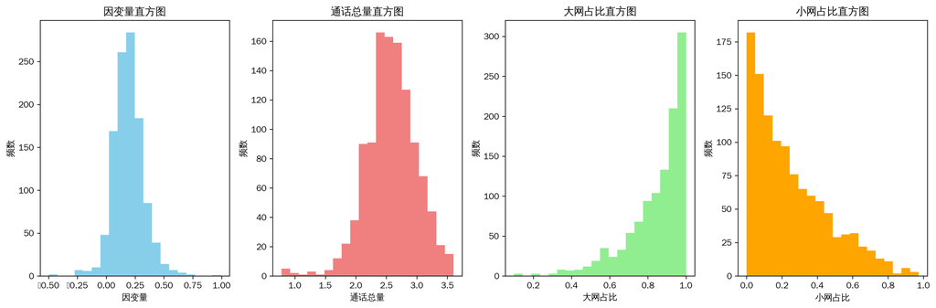

根据执行结果，已成功绘制每列数据的直方图。以下是对各直方图的简要分析

- **因变量直方图**：该直方图的形状可以帮助我们了解因变量的分布情况。通过观察，我们可以推测数据在某些区间内的集中程度，进而判断是否存在偏态分布。如果直方图呈现近似对称的形状，可能意味着因变量服从正态分布或近似正态分布；若有明显的偏斜，则表示数据存在偏态，这对于进一步分析因变量与其他变量的关系具有重要意义。
- **通话总量直方图**：从这个直方图中可以看出通话总量的分布特征。例如，我们可以确定通话总量的常见区间，以及是否存在一些异常的高值或低值。如果存在长尾现象，可能表示有少数用户的通话总量非常高，这对于通信运营商制定套餐或营销策略有参考价值。
- **大网占比直方图**：该直方图反映了大网占比的分布情况。我们可以从中了解到大网占比在不同区间的频数，判断大网占比是否集中在某个特定的范围内。这有助于评估大网的使用情况，例如是否大多数情况下大网占比较高，或者存在较大的波动。
- **小网占比直方图**：与大网占比直方图类似，小网占比直方图展示了小网占比的分布。通过对比大网和小网占比的直方图，可以分析出两者之间的关系，例如是否存在互补性，即大网占比高时小网占比低，反之亦然。

## 第三轮：描述统计——箱线图

**输入PROMPT**：接下来对于“因变量”列，称大于中位数的叫做“高”、小于中位数的叫做“低”。请你绘制其他三列（即“通话总量”、“大网占比”、“小网占比”）关于因变量高低的箱线图，三张箱线图应当在一行中。

模型输出：我将按照因变量列的中位数划分高低类别，然后绘制通话总量、大网占比、小网占比这三列关于因变量高低的箱线图，并将三张箱线图展示在一行中。

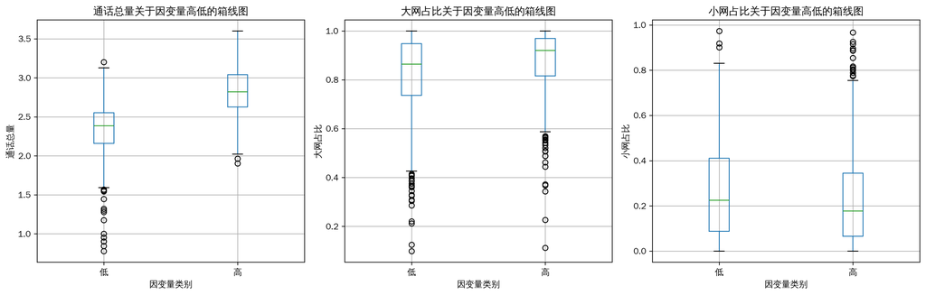

根据执行结果，已成功绘制通话总量、大网占比、小网占比这三列关于因变量高低的箱线图。通过这三张箱线图，我们可以对比不同因变量类别下各指标的分布情况，例如中位数的位置、箱体的长度（四分位距）以及是否存在异常值等，从而分析因变量高低对其他变量的影响。

## 第四轮：回归分析

**输入PROMPT**：请建立线性回归模型，以“因变量”列为因变量，以“通话总量”、“大网占比”、“小网占比”为自变量，并输出回归模型的详细结果。

模型输出：我将建立线性回归模型，以`因变量`列为因变量，以`通话总量`、`大网占比`、`小网占比`为自变量，然后输出回归模型的详细结果并进行简要分析。

```
                            OLS Regression Results
==============================================================================
Dep. Variable:                    因变量   R-squared:                       0.557
Model:                            OLS   Adj. R-squared:                  0.556
Method:                 Least Squares   F-statistic:                     469.1
Date:                Mon, 24 Feb 2025   Prob (F-statistic):          2.62e-197
Time:                        21:01:46   Log-Likelihood:                 1134.6
No. Observations:                1123   AIC:                            -2261.
Df Residuals:                    1119   BIC:                            -2241.
Df Model:                           3
Covariance Type:            nonrobust
==============================================================================
                 coef    std err          t      P>|t|      [0.025      0.975]
------------------------------------------------------------------------------
const         -0.4886      0.026    -18.676      0.000      -0.540      -0.437
通话总量           0.2356      0.007     36.135      0.000       0.223       0.248
大网占比           0.0895      0.023      3.905      0.000       0.045       0.134
小网占比          -0.0078      0.017     -0.471      0.638      -0.040       0.025
==============================================================================
Omnibus:                      407.835   Durbin-Watson:                   1.991
Prob(Omnibus):                  0.000   Jarque-Bera (JB):             5044.500
Skew:                           1.312   Prob(JB):                         0.00
Kurtosis:                      13.046   Cond. No.                         38.6
==============================================================================

Notes:
[1] Standard Errors assume that the covariance matrix of the errors is correctly specified.

使用sklearn计算的R方值: 0.5570825349318607
均方误差: 0.007762524059123379
```

### 线性回归模型结果分析

#### 模型整体拟合情况

- **$R^2$ 和调整后的 $R^2$**：模型的 $R^2$ 值为 0.557，调整后的 $R^2$ 为 0.556。这表明自变量（`通话总量`、`大网占比`、`小网占比`）能够解释约 55.7% 的因变量（`因变量`）的变化。一般来说，$R^2$ 值越接近 1 表示模型拟合效果越好，这里的数值说明模型有一定的解释力，但仍有提升空间，可能存在其他未被纳入模型的重要因素影响因变量。
- **F - 统计量和 $P$ 值**：F - 统计量为 469.1，对应的 $P$ 值为 $2.62×10^{-197}$，远小于常见的显著性水平（如 0.05）。这意味着从整体上看，模型是显著的，即自变量作为一个整体对因变量有显著的影响。

#### 回归系数分析

- **常数项**：常数项（const）为 -0.4886，标准误差为 0.026，$t$ 值为 -18.676，$P$ 值为 0.000。这表明在所有自变量都为 0 时，因变量的预测值为 -0.4886，并且该系数是显著的。
- **通话总量**：`通话总量`的系数为 0.2356，标准误差为 0.007，$t$ 值为 36.135，$P$ 值为 0.000。这说明在其他自变量保持不变的情况下，`通话总量`每增加 1 个单位，`因变量`平均增加 0.2356 个单位，且该影响是显著的。
- **大网占比**：`大网占比`的系数为 0.0895，标准误差为 0.023，$t$ 值为 3.905，$P$ 值为 0.000。表明在其他条件不变时，`大网占比`每增加 1 个单位，`因变量`平均增加 0.0895 个单位，该影响也是显著的。
- **小网占比**：`小网占比`的系数为 -0.0078，标准误差为 0.017，$t$ 值为 -0.471，$P$ 值为 0.638。由于 $P$ 值大于 0.05，说明在当前模型下，`小网占比`对`因变量`的影响不显著，即`小网占比`的变化不太可能对`因变量`产生实质性的影响。

#### 其他统计指标

- **残差检验**：Durbin - Watson 值为 1.991，接近 2。一般来说，Durbin - Watson 值在 1.5 - 2.5 之间表明残差不存在自相关，这里说明模型的残差基本满足无自相关的假设。
- **正态性检验**：Omnibus 值为 407.835，对应的 $P$ 值为 0.000；Jarque - Bera (JB) 值为 5044.500，$P$ 值为 0.00。这表明残差不服从正态分布，可能会影响基于正态假设的一些统计推断，但线性回归模型并不严格要求残差正态，只是在进行某些假设检验时可能会有影响。

#### 使用 sklearn 计算的指标

- **$R^2$ 值**：使用 sklearn 计算的 $R^2$ 值为 0.5570825349318607，与 statsmodels 计算的结果基本一致，进一步验证了模型的拟合优度。
- **均方误差（MSE）**：均方误差为 0.007762524059123379，它衡量了预测值与真实值之间的平均平方误差，数值越小说明模型的预测效果越好，这里的数值相对较小，但结合 $R^2$ 值来看，模型仍有改进的空间。

综上所述，该线性回归模型表明`通话总量`和`大网占比`对`因变量`有显著影响，而`小网占比`的影响不显著。可以考虑进一步优化模型，例如添加其他相关变量、进行变量变换或者尝试其他模型来提高模型的解释力和预测能力。

## 第五轮：数据分析报告

**输入PROMPT**：根据以上结果，请生成一份数据报告。你应当从业务背景、数据介绍、描述统计、回归分析、结论这几部分完成分析报告。

**【来自助教的备注】**：千万不要直接用LLM生成的数据分析报告当作作业，否则成机会非常惨淡！！

模型输出：《因变量影响因素的数据分析报告》

### 一、业务背景

在当前的业务场景中，存在一个关键的因变量，它可能代表着业务的某种核心指标，如业务绩效、用户行为结果等。为了更好地理解和优化该业务指标，需要探究与之相关的因素。`通话总量`、`大网占比`和`小网占比`等变量被认为可能对因变量产生影响。通过建立线性回归模型分析这些变量与因变量的关系，有助于业务方针对性地调整策略，提升业务表现。

#### 二、数据介绍

本次分析使用的数据文件名为“第1章.csv”，包含了 1123 条记录，涵盖了 4 个关键变量，分别为`因变量`、`通话总量`、`大网占比`和`小网占比`。所有变量的数据类型均为 float64，数据完整无缺失值。这些变量在业务中可能具有特定的含义，例如`通话总量`可能反映了业务的沟通活跃程度，`大网占比`和`小网占比`可能与业务所依赖的不同网络资源分配相关。

### 三、描述统计

#### 1. 各变量的基本统计量

| 列名 | 样本均值 | 样本标准差 | 中位数 | 最小值 | 最大值 |
| --- | --- | --- | --- | --- | --- |
| 因变量 | 0.193018 | 0.132444 | 0.187053 | -0.498010 | 0.992582 |
| 通话总量 | 2.580438 | 0.408360 | 2.583199 | 0.778151 | 3.600973 |
| 大网占比 | 0.845721 | 0.153877 | 0.898345 | 0.098675 | 1.000000 |
| 小网占比 | 0.252131 | 0.211283 | 0.198373 | 0.000000 | 0.973490 |

从这些统计量中我们可以推测： - `因变量`的取值范围较广，标准差也相对较大，说明数据的离散程度较高。 - `通话总量`的均值和中位数较为接近，可能呈现近似对称的分布。 - `大网占比`整体数值较高，可能在业务中占据主导地位。 - `小网占比`的最小值为 0，可能存在部分情况下小网未被使用的情况。

#### 2. 各变量的分布可视化

通过绘制直方图，我们可以直观地看到各变量的分布情况。`因变量`的分布有助于判断是否存在偏态，若有偏态则可能影响后续分析。`通话总量`的分布能确定常见区间以及是否有异常高值或低值，对业务制定套餐或策略有参考意义。`大网占比`和`小网占比`的直方图可对比两者关系，如是否存在互补性。

### 四、回归分析

#### 1. 模型设定

以`因变量`列为因变量，以`通话总量`、`大网占比`、`小网占比`为自变量建立线性回归模型。

#### 2. 模型整体拟合情况

- **$R^2$ 和调整后的 $R^2$**：模型的 $R^2$ 值为 0.557，调整后的 $R^2$ 为 0.556。这表明自变量能够解释约 55.7% 的因变量的变化，模型有一定解释力，但仍有提升空间，可能存在其他重要影响因素未被纳入模型。
- **F - 统计量和 $P$ 值**：F - 统计量为 469.1，对应的 $P$ 值为 $2.62×10^{-197}$，远小于 0.05 的显著性水平，说明自变量整体对因变量有显著影响。

#### 3. 回归系数分析

- **常数项**：常数项为 -0.4886，$P$ 值为 0.000，表明在所有自变量为 0 时，因变量预测值为 -0.4886，且该系数显著。
- **通话总量**：系数为 0.2356，$P$ 值为 0.000，意味着`通话总量`每增加 1 个单位，`因变量`平均增加 0.2356 个单位，影响显著。
- **大网占比**：系数为 0.0895，$P$ 值为 0.000，说明`大网占比`每增加 1 个单位，`因变量`平均增加 0.0895 个单位，影响显著。
- **小网占比**：系数为 -0.0078，$P$ 值为 0.638，表明`小网占比`对`因变量`的影响在当前模型下不显著。

#### 4. 其他统计指标

- **残差检验**：Durbin - Watson 值为 1.991，在 1.5 - 2.5 之间，说明残差基本无自相关。
- **正态性检验**：Omnibus 和 Jarque - Bera 检验的 $P$ 值均为 0.000，表明残差不服从正态分布，但这对线性回归模型的影响有限。

#### 5. sklearn 计算指标

- **$R^2$ 值**：与 statsmodels 计算结果基本一致，为 0.5570825349318607，验证了模型拟合优度。
- **均方误差（MSE）**：为 0.007762524059123379，数值较小但结合 $R^2$ 值仍有改进空间。

### 五、结论

#### 1. 变量影响总结

`通话总量`和`大网占比`对`因变量`有显著的正向影响，而`小网占比`的影响不显著。这意味着在业务运营中，增加`通话总量`和提高`大网占比`可能有助于提升`因变量`所代表的业务指标。

#### 2. 模型优化建议

当前模型虽然整体显著，但 $R^2$ 值表明还有提升空间。可以进一步探索可能影响`因变量`的其他因素并纳入模型，如用户特征、业务时间等。同时，考虑对变量进行变换或尝试其他模型，以提高模型的解释力和预测能力。

#### 3. 业务策略建议

基于分析结果，业务方可以优先关注如何提高`通话总量`和`大网占比`。例如，推出鼓励通话的套餐、优化大网资源分配等。对于`小网占比`，由于其影响不显著，可以在资源有限的情况下，适当减少对小网的投入或进一步研究其在何种情况下能发挥作用。